# A3.2 Redes Neuronales

## Luis Enrique Garcia Gallegos

### **Matricula:** 649247

En esta actividad trabajarás con la base de datos de imágenes del MNIST, misma que se usó en el Taller de Redes Neuronales. Desarrolla los siguientes puntos en una *Jupyter Notebook*, tratando, dentro de lo posible, que cada punto se trabaje en una celda distinta. Los comentarios en el código siempre son bienvenidos, de preferencia, aprovecha el *markdown* para generar cuadros de descripción que ayuden al lector a comprender el trabajo realizado.

1. Entrena un modelo de redes neuronales para clasificar los dígitos de **0** al **9**, y muestra mediante gráficas el comportamiento del sistema a lo largo del entrenamiento. Especifica la exactitud del modelo tanto en entrenamiento como en validación.

```
Model: "sequential"
```

```
┏━━━━━━━━━━━━━━━━━━━━━━━━━━━━━━━━━┳━━━━━━━━━━━━━━━━━━━━━━━━┳━━━━━━━━━━━━━━━┓
┃ Layer (type)                    ┃ Output Shape           ┃       Param # ┃
┡━━━━━━━━━━━━━━━━━━━━━━━━━━━━━━━━━╇━━━━━━━━━━━━━━━━━━━━━━━━╇━━━━━━━━━━━━━━━┩
│ flatten (Flatten)               │ (None, 784)            │             0 │
├─────────────────────────────────┼────────────────────────┼───────────────┤
│ dense (Dense)                   │ (None, 256)            │       200,960 │
├─────────────────────────────────┼────────────────────────┼───────────────┤
│ dense_1 (Dense)                 │ (None, 128)            │        32,896 │
├─────────────────────────────────┼────────────────────────┼───────────────┤
│ dense_2 (Dense)                 │ (None, 64)             │         8,256 │
├─────────────────────────────────┼────────────────────────┼───────────────┤
│ dense_3 (Dense)                 │ (None, 10)             │           650 │
└─────────────────────────────────┴────────────────────────┴───────────────┘
```

```
 Total params: 242,762 (948.29 KB)
```

```
 Trainable params: 242,762 (948.29 KB)
```

```
 Non-trainable params: 0 (0.00 B)
```

```
1125/1125 ━━━━━━━━━━━━━━━━━━━━ 2s 2ms/step - accuracy: 0.8056 - loss: 3.9382 - val_accuracy: 0.9008 - val_loss: 0.4548
1125/1125 ━━━━━━━━━━━━━━━━━━━━ 2s 2ms/step - accuracy: 0.9296 - loss: 0.2977 - val_accuracy: 0.9200 - val_loss: 0.3212
1125/1125 ━━━━━━━━━━━━━━━━━━━━ 2s 2ms/step - accuracy: 0.9461 - loss: 0.1901 - val_accuracy: 0.9279 - val_loss: 0.3052
1125/1125 ━━━━━━━━━━━━━━━━━━━━ 2s 2ms/step - accuracy: 0.9531 - loss: 0.1667 - val_accuracy: 0.9461 - val_loss: 0.2195
1125/1125 ━━━━━━━━━━━━━━━━━━━━ 2s 2ms/step - accuracy: 0.9621 - loss: 0.1363 - val_accuracy: 0.9465 - val_loss: 0.2164
1125/1125 ━━━━━━━━━━━━━━━━━━━━ 2s 2ms/step - accuracy: 0.9674 - loss: 0.1162 - val_accuracy: 0.9580 - val_loss: 0.1733
1125/1125 ━━━━━━━━━━━━━━━━━━━━ 2s 2ms/step - accuracy: 0.9682 - loss: 0.1085 - val_accuracy: 0.9595 - val_loss: 0.1777
1125/1125 ━━━━━━━━━━━━━━━━━━━━ 2s 2ms/step - accuracy: 0.9750 - loss: 0.0855 - val_accuracy: 0.9611 - val_loss: 0.1761
1125/1125 ━━━━━━━━━━━━━━━━━━━━ 2s 2ms/step - accuracy: 0.9754 - loss: 0.0831 - val_accuracy: 0.9582 - val_loss: 0.1673
1125/1125 ━━━━━━━━━━━━━━━━━━━━ 2s 2ms/step - accuracy: 0.9784 - loss: 0.0728 - val_accuracy: 0.9614 - val_loss: 0.1654
1125/1125 ━━━━━━━━━━━━━━━━━━━━ 2s 2ms/step - accuracy: 0.9812 - loss: 0.0661 - val_accuracy: 0.9626 - val_loss: 0.1598
1125/1125 ━━━━━━━━━━━━━━━━━━━━ 2s 2ms/step - accuracy: 0.9843 - loss: 0.0562 - val_accuracy: 0.9647 - val_loss: 0.1807
1125/1125 ━━━━━━━━━━━━━━━━━━━━ 2s 2ms/step - accuracy: 0.9829 - loss: 0.0580 - val_accuracy: 0.9597 - val_loss: 0.2112
1125/1125 ━━━━━━━━━━━━━━━━━━━━ 2s 2ms/step - accuracy: 0.9842 - loss: 0.0534 - val_accuracy: 0.9604 - val_loss: 0.1946
1125/1125 ━━━━━━━━━━━━━━━━━━━━ 2s 2ms/step - accuracy: 0.9870 - loss: 0.0462 - val_accuracy: 0.9663 - val_loss: 0.1763
1125/1125 ━━━━━━━━━━━━━━━━━━━━ 2s 2ms/step - accuracy: 0.9854 - loss: 0.0497 - val_accuracy: 0.9686 - val_loss: 0.1855
1125/1125 ━━━━━━━━━━━━━━━━━━━━ 2s 2ms/step - accuracy: 0.9870 - loss: 0.0488 - val_accuracy: 0.9680 - val_loss: 0.1662
1125/1125 ━━━━━━━━━━━━━━━━━━━━ 2s 2ms/step - accuracy: 0.9871 - loss: 0.0490 - val_accuracy: 0.9690 - val_loss: 0.1844
1125/1125 ━━━━━━━━━━━━━━━━━━━━ 2s 2ms/step - accuracy: 0.9919 - loss: 0.0321 - val_accuracy: 0.9696 - val_loss: 0.1850
1125/1125 ━━━━━━━━━━━━━━━━━━━━ 2s 2ms/step - accuracy: 0.9902 - loss: 0.0339 - val_accuracy: 0.9685 - val_loss: 0.1887
1125/1125 ━━━━━━━━━━━━━━━━━━━━ 2s 2ms/step - accuracy: 0.9923 - loss: 0.0306 - val_accuracy: 0.9672 - val_loss: 0.1872
1125/1125 ━━━━━━━━━━━━━━━━━━━━ 2s 2ms/step - accuracy: 0.9924 - loss: 0.0296 - val_accuracy: 0.9627 - val_loss: 0.2853
1125/1125 ━━━━━━━━━━━━━━━━━━━━ 2s 2ms/step - accuracy: 0.9894 - loss: 0.0431 - val_accuracy: 0.9698 - val_loss: 0.2050
1125/1125 ━━━━━━━━━━━━━━━━━━━━ 2s 2ms/step - accuracy: 0.9927 - loss: 0.0289 - val_accuracy: 0.9663 - val_loss: 0.2226
1125/1125 ━━━━━━━━━━━━━━━━━━━━ 2s 2ms/step - accuracy: 0.9917 - loss: 0.0338 - val_accuracy: 0.9675 - val_loss: 0.2507
1125/1125 ━━━━━━━━━━━━━━━━━━━━ 2s 2ms/step - accuracy: 0.9912 - loss: 0.0368 - val_accuracy: 0.9618 - val_loss: 0.3492
1125/1125 ━━━━━━━━━━━━━━━━━━━━ 2s 2ms/step - accuracy: 0.9911 - loss: 0.0410 - val_accuracy: 0.9691 - val_loss: 0.2608
1125/1125 ━━━━━━━━━━━━━━━━━━━━ 2s 2ms/step - accuracy: 0.9925 - loss: 0.0367 - val_accuracy: 0.9718 - val_loss: 0.2384
1125/1125 ━━━━━━━━━━━━━━━━━━━━ 2s 2ms/step - accuracy: 0.9921 - loss: 0.0421 - val_accuracy: 0.9727 - val_loss: 0.2366
1125/1125 ━━━━━━━━━━━━━━━━━━━━ 2s 2ms/step - accuracy: 0.9940 - loss: 0.0250 - val_accuracy: 0.9707 - val_loss: 0.2661
1125/1125 ━━━━━━━━━━━━━━━━━━━━ 2s 2ms/step - accuracy: 0.9933 - loss: 0.0315 - val_accuracy: 0.9698 - val_loss: 0.2797
1125/1125 ━━━━━━━━━━━━━━━━━━━━ 2s 2ms/step - accuracy: 0.9903 - loss: 0.0430 - val_accuracy: 0.9671 - val_loss: 0.3009
1125/1125 ━━━━━━━━━━━━━━━━━━━━ 2s 1ms/step - accuracy: 0.9942 - loss: 0.0288 - val_accuracy: 0.9693 - val_loss: 0.2199
1125/1125 ━━━━━━━━━━━━━━━━━━━━ 2s 2ms/step - accuracy: 0.9949 - loss: 0.0220 - val_accuracy: 0.9691 - val_loss: 0.2854
1125/1125 ━━━━━━━━━━━━━━━━━━━━ 2s 2ms/step - accuracy: 0.9935 - loss: 0.0335 - val_accuracy: 0.9695 - val_loss: 0.2676
1125/1125 ━━━━━━━━━━━━━━━━━━━━ 2s 2ms/step - accuracy: 0.9941 - loss: 0.0293 - val_accuracy: 0.9724 - val_loss: 0.2787
1125/1125 ━━━━━━━━━━━━━━━━━━━━ 2s 1ms/step - accuracy: 0.9941 - loss: 0.0306 - val_accuracy: 0.9705 - val_loss: 0.2680
1125/1125 ━━━━━━━━━━━━━━━━━━━━ 2s 2ms/step - accuracy: 0.9952 - loss: 0.0206 - val_accuracy: 0.9692 - val_loss: 0.2855
1125/1125 ━━━━━━━━━━━━━━━━━━━━ 2s 2ms/step - accuracy: 0.9952 - loss: 0.0247 - val_accuracy: 0.9703 - val_loss: 0.2913
1125/1125 ━━━━━━━━━━━━━━━━━━━━ 2s 2ms/step - accuracy: 0.9965 - loss: 0.0155 - val_accuracy: 0.9714 - val_loss: 0.2261
1125/1125 ━━━━━━━━━━━━━━━━━━━━ 2s 2ms/step - accuracy: 0.9951 - loss: 0.0211 - val_accuracy: 0.9684 - val_loss: 0.2791
1125/1125 ━━━━━━━━━━━━━━━━━━━━ 2s 2ms/step - accuracy: 0.9934 - loss: 0.0345 - val_accuracy: 0.9697 - val_loss: 0.3346
1125/1125 ━━━━━━━━━━━━━━━━━━━━ 2s 2ms/step - accuracy: 0.9937 - loss: 0.0389 - val_accuracy: 0.9708 - val_loss: 0.2962
1125/1125 ━━━━━━━━━━━━━━━━━━━━ 2s 2ms/step - accuracy: 0.9964 - loss: 0.0170 - val_accuracy: 0.9718 - val_loss: 0.2817
```

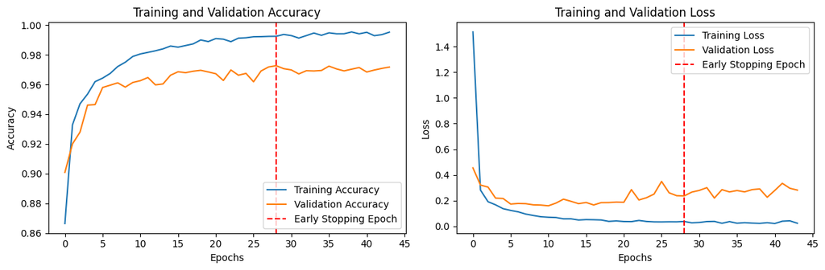

```python
import numpy as np
import matplotlib.pyplot as plt
import tensorflow as tf
import seaborn as sns
import cv2
from sklearn.metrics import confusion_matrix
from tensorflow.keras.datasets import mnist
from tensorflow.keras.models import Sequential
from tensorflow.keras.layers import Flatten, Dense
from tensorflow.keras.callbacks import EarlyStopping
from tensorflow.keras.optimizers import Adam
from tensorflow.keras import layers
from matplotlib.ticker import MaxNLocator
(train_images, train_labels), (test_images, test_labels)=mnist.load_data()
modelo=Sequential()
modelo.add(Flatten(input_shape=(28, 28)))
modelo.add(Dense(256, activation='relu'))
modelo.add(Dense(128, activation='relu'))
modelo.add(Dense(64, activation='relu'))
modelo.add(Dense(10, activation='softmax'))
modelo.compile(optimizer='adam', loss='sparse_categorical_crossentropy', metrics=['accuracy'])
modelo.summary()
early_stop=EarlyStopping(monitor='val_accuracy', patience=15, restore_best_weights=True)
history=modelo.fit(train_images, train_labels, epochs=100, validation_split=0.4, batch_size=32, callbacks=[early_stop])
stopped_epoch=early_stop.stopped_epoch
best_epoch=stopped_epoch-early_stop.patience
plt.figure(figsize=(12, 4))
plt.subplot(1, 2, 1)
plt.plot(history.history['accuracy'], label='Training Accuracy')
plt.plot(history.history['val_accuracy'], label='Validation Accuracy')
plt.axvline(x=best_epoch, color='r', linestyle='--', label='Early Stopping Epoch')
plt.title('Training and Validation Accuracy')
plt.xlabel('Epochs')
plt.ylabel('Accuracy')
plt.gca().xaxis.set_major_locator(MaxNLocator(integer=True))
plt.legend()
plt.subplot(1, 2, 2)
plt.plot(history.history['loss'], label='Training Loss')
plt.plot(history.history['val_loss'], label='Validation Loss')
plt.axvline(x=best_epoch, color='r', linestyle='--', label='Early Stopping Epoch')
plt.title('Training and Validation Loss')
plt.xlabel('Epochs')
plt.ylabel('Loss')
plt.gca().xaxis.set_major_locator(MaxNLocator(integer=True))
plt.legend()
plt.tight_layout()
plt.show()
```

Este es un modelo de redes neuronales muy simple realizado durante el taller de redes neuronales, como se ve en el histograma vemos que hay deja de haber diferencias significativas alrededor del modelo 28, además de que entre el entrenamiento y validación notamos que hay diferencias notables.

2. Evalúa la exactitud del modelo en el conjunto de prueba generado al cargar la base de datos y compárala con la exactitud de validación del modelo. Realiza un comentario sobre los resultados de dicha comparación.

```python
test_loss, test_accuracy=modelo.evaluate(test_images, test_labels)
print(f'Exactitud en el conjunto de prueba: {test_accuracy:.4f}')
best_val_accuracy=max(history.history['val_accuracy'])
print(f'Máxima exactitud en validación: {best_val_accuracy:.4f}')
```

```
313/313 ━━━━━━━━━━━━━━━━━━━━ 0s 693us/step - accuracy: 0.9708 - loss: 0.2768
Exactitud en el conjunto de prueba: 0.9762
Máxima exactitud en validación: 0.9727
```

Este código fue proporcionado por ChatGpt y algo importante a destacar es que cuando probamos los datos de entrenamiento vemos que los accuracy son bastante similares aunque un poco diferente que el de entrenamiento.

3. Genera **50 imágenes**, **5** para cada dígito. Preprocesa las imágenes para que puedan ser evaluadas por el modelo, de forma similar a como se realizó en el taller.

```
1/1 ━━━━━━━━━━━━━━━━━━━━ 0s 41ms/step
Predicción: 8, Etiqueta verdadera: 1
```

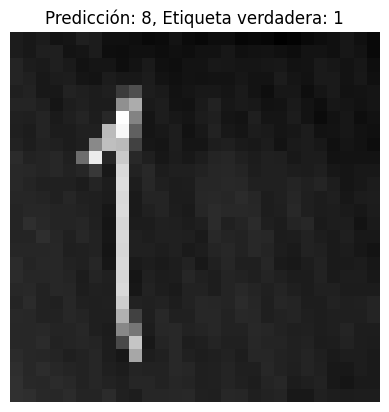

```
1/1 ━━━━━━━━━━━━━━━━━━━━ 0s 20ms/step
Predicción: 8, Etiqueta verdadera: 1
```

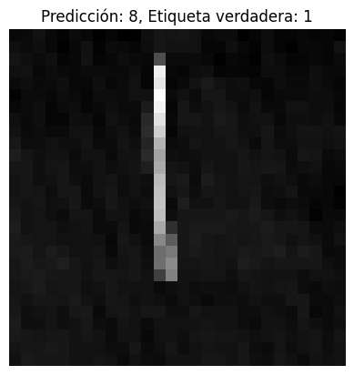

```
1/1 ━━━━━━━━━━━━━━━━━━━━ 0s 30ms/step
Predicción: 2, Etiqueta verdadera: 1
```

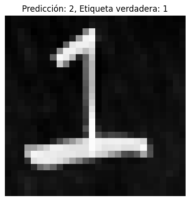

```
1/1 ━━━━━━━━━━━━━━━━━━━━ 0s 19ms/step
Predicción: 8, Etiqueta verdadera: 1
```

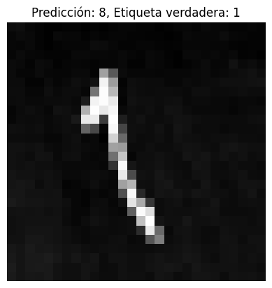

```
1/1 ━━━━━━━━━━━━━━━━━━━━ 0s 20ms/step
Predicción: 8, Etiqueta verdadera: 1
```

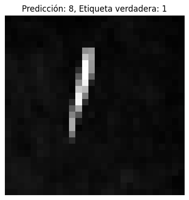

```
1/1 ━━━━━━━━━━━━━━━━━━━━ 0s 19ms/step
Predicción: 2, Etiqueta verdadera: 2
```

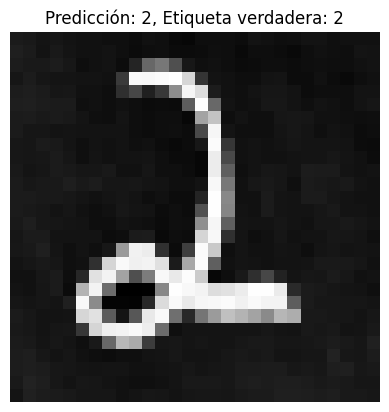

```
1/1 ━━━━━━━━━━━━━━━━━━━━ 0s 21ms/step
Predicción: 2, Etiqueta verdadera: 2
```

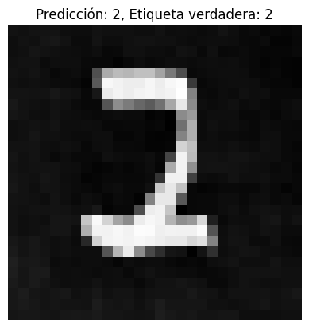

```
1/1 ━━━━━━━━━━━━━━━━━━━━ 0s 20ms/step
Predicción: 2, Etiqueta verdadera: 2
```

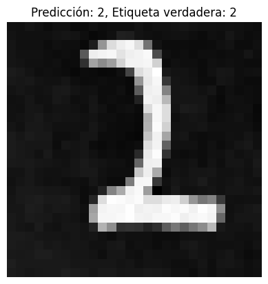

```
1/1 ━━━━━━━━━━━━━━━━━━━━ 0s 20ms/step
Predicción: 9, Etiqueta verdadera: 2
```

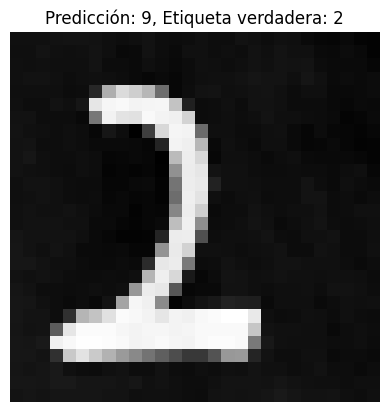

```
1/1 ━━━━━━━━━━━━━━━━━━━━ 0s 22ms/step
Predicción: 3, Etiqueta verdadera: 2
```

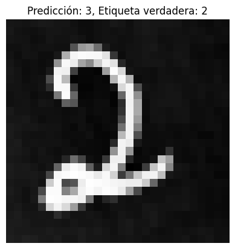

```
1/1 ━━━━━━━━━━━━━━━━━━━━ 0s 20ms/step
Predicción: 8, Etiqueta verdadera: 3
```

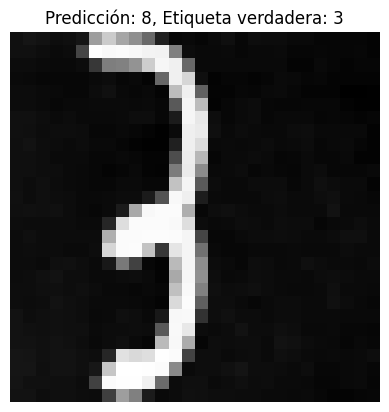

```
1/1 ━━━━━━━━━━━━━━━━━━━━ 0s 21ms/step
Predicción: 3, Etiqueta verdadera: 3
```

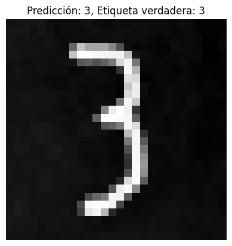

```
1/1 ━━━━━━━━━━━━━━━━━━━━ 0s 20ms/step
Predicción: 3, Etiqueta verdadera: 3
```

[38 more figures not shown]

```python
true_labels={1: 1, 2: 1, 3: 1, 4: 1, 5: 1, 6: 2, 7: 2, 8: 2, 9: 2, 10: 2, 11: 3, 12: 3, 13: 3, 14: 3, 15: 3, 16: 4, 17: 4, 18: 4, 19: 4, 20: 4, 21: 5, 22: 5, 23: 5, 24: 5, 25: 5, 26: 6, 27: 6, 28: 6, 29: 6, 30: 6, 31: 7, 32: 7, 33: 7, 34: 7, 35: 7, 36: 8, 37: 8, 38: 8, 39: 8, 40: 8, 41: 9, 42: 9, 43: 9, 44: 9, 45: 9, 46: 0, 47: 0, 48: 0, 49: 0, 50: 0}
y_true=[true_labels[i] for i in range(1, 51)]
y_pred=[]
correct_count=0
total_count=0
def convert_to_mnist_format(image_path):
    img=cv2.imread(image_path)
    gray=cv2.cvtColor(img, cv2.COLOR_BGR2GRAY)
    gray=255-gray
    resized=cv2.resize(gray, (28, 28), interpolation=cv2.INTER_AREA)
    final_image=resized.reshape(1, 28, 28, 1)
    return final_image
for i in range(1, 51):
    image_path=f'imagen{i}.jpg'
    final_image=convert_to_mnist_format(image_path)
    prediction=modelo.predict(final_image)
    predicted_label=np.argmax(prediction, axis=1)[0]
    y_pred.append(predicted_label)
    true_label=true_labels[i]
    if predicted_label==true_label:
        correct_count+=1
    total_count+=1
    print(f'Predicción: {predicted_label}, Etiqueta verdadera: {true_label}')
    plt.imshow(final_image[0].reshape(28, 28), cmap='gray')
    plt.title(f'Predicción: {predicted_label}, Etiqueta verdadera: {true_label}')
    plt.axis('off')
    plt.show()
```

El código fue hecho en parte por Claude, pero vemos como nuestro modelo se comporta ante las imágenes que le dimos que fueron hechas a maño y se subieron al repositorio, vemos que son similares que la del base de datos, no obstante vemos que el modelo dice que la mayoría de las imágenes son un 8, cuando en realidad unicamente 5 lo son.

4. Evalúa el desempeño del modelo en dichas imágenes. Compara los resultados con los previos y comenta motivos de potencial error.

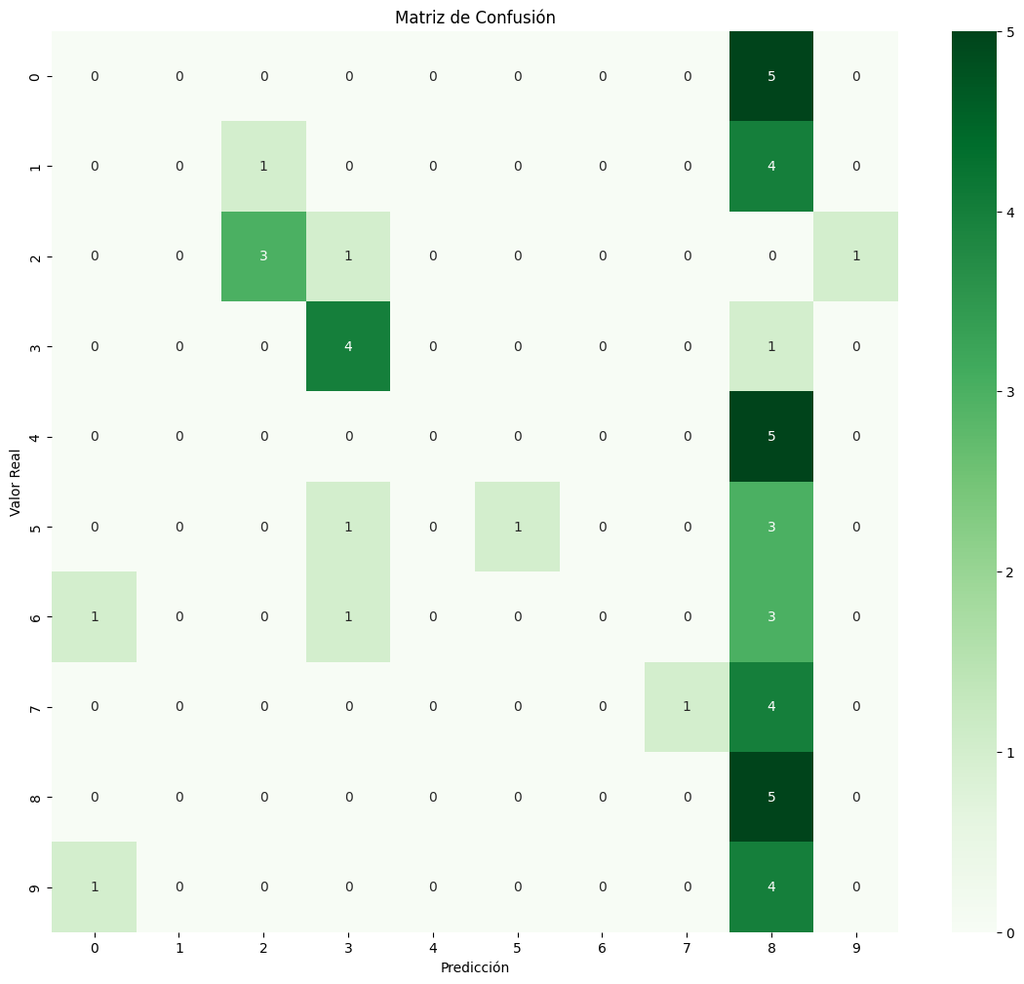

```
Accuracy: 0.2800 (14/50)
```

```python
accuracy=correct_count/total_count
plt.figure(figsize=(14, 12))
cm=confusion_matrix(y_true, y_pred, labels=range(10))
sns.heatmap(cm, annot=True, fmt='d', cmap='Greens', xticklabels=range(10), yticklabels=range(10))
plt.xlabel('Predicción')
plt.ylabel('Valor Real')
plt.title('Matriz de Confusión')
plt.show()
print(f"Accuracy: {accuracy:.4f} ({correct_count}/{total_count})")
```

Esto también fue una parte hecha por Claude, sin embargo podemos ver que solamente le acertó a 14 de las 50 imágenes, por lo que aun no es buen modelo, o probablemente tuvimos un sobreajuste con los datos de entrenamiento.

5. Genera **3 mejoras**, **innovaciones**, o **adiciones** al sistema actual (pueden ser para cualquier etapa, desde la carga de datos, hasta los resultados de la predicción). Indica claramente qué se hizo, por qué, y si culminaron en mejoras en la predicción o en la funcionalidad del sistema.

```
Model: "sequential_1"
```

```
┏━━━━━━━━━━━━━━━━━━━━━━━━━━━━━━━━━┳━━━━━━━━━━━━━━━━━━━━━━━━┳━━━━━━━━━━━━━━━┓
┃ Layer (type)                    ┃ Output Shape           ┃       Param # ┃
┡━━━━━━━━━━━━━━━━━━━━━━━━━━━━━━━━━╇━━━━━━━━━━━━━━━━━━━━━━━━╇━━━━━━━━━━━━━━━┩
│ conv2d (Conv2D)                 │ (None, 28, 28, 32)     │           320 │
├─────────────────────────────────┼────────────────────────┼───────────────┤
│ max_pooling2d (MaxPooling2D)    │ (None, 14, 14, 32)     │             0 │
├─────────────────────────────────┼────────────────────────┼───────────────┤
│ conv2d_1 (Conv2D)               │ (None, 14, 14, 64)     │        18,496 │
├─────────────────────────────────┼────────────────────────┼───────────────┤
│ max_pooling2d_1 (MaxPooling2D)  │ (None, 7, 7, 64)       │             0 │
├─────────────────────────────────┼────────────────────────┼───────────────┤
│ flatten_1 (Flatten)             │ (None, 3136)           │             0 │
├─────────────────────────────────┼────────────────────────┼───────────────┤
│ dense_4 (Dense)                 │ (None, 128)            │       401,536 │
├─────────────────────────────────┼────────────────────────┼───────────────┤
│ dense_5 (Dense)                 │ (None, 10)             │         1,290 │
└─────────────────────────────────┴────────────────────────┴───────────────┘
```

```
 Total params: 421,642 (1.61 MB)
```

```
 Trainable params: 421,642 (1.61 MB)
```

```
 Non-trainable params: 0 (0.00 B)
```

```
1125/1125 ━━━━━━━━━━━━━━━━━━━━ 4s 4ms/step - accuracy: 0.8880 - loss: 0.3561 - val_accuracy: 0.9788 - val_loss: 0.0704
1125/1125 ━━━━━━━━━━━━━━━━━━━━ 4s 4ms/step - accuracy: 0.9846 - loss: 0.0501 - val_accuracy: 0.9819 - val_loss: 0.0575
1125/1125 ━━━━━━━━━━━━━━━━━━━━ 4s 3ms/step - accuracy: 0.9897 - loss: 0.0318 - val_accuracy: 0.9869 - val_loss: 0.0442
1125/1125 ━━━━━━━━━━━━━━━━━━━━ 4s 3ms/step - accuracy: 0.9941 - loss: 0.0180 - val_accuracy: 0.9850 - val_loss: 0.0545
1125/1125 ━━━━━━━━━━━━━━━━━━━━ 4s 3ms/step - accuracy: 0.9955 - loss: 0.0142 - val_accuracy: 0.9887 - val_loss: 0.0419
1125/1125 ━━━━━━━━━━━━━━━━━━━━ 4s 3ms/step - accuracy: 0.9962 - loss: 0.0103 - val_accuracy: 0.9890 - val_loss: 0.0460
1125/1125 ━━━━━━━━━━━━━━━━━━━━ 4s 3ms/step - accuracy: 0.9966 - loss: 0.0101 - val_accuracy: 0.9861 - val_loss: 0.0598
1125/1125 ━━━━━━━━━━━━━━━━━━━━ 4s 3ms/step - accuracy: 0.9982 - loss: 0.0059 - val_accuracy: 0.9859 - val_loss: 0.0614
1125/1125 ━━━━━━━━━━━━━━━━━━━━ 4s 3ms/step - accuracy: 0.9969 - loss: 0.0087 - val_accuracy: 0.9869 - val_loss: 0.0585
1125/1125 ━━━━━━━━━━━━━━━━━━━━ 4s 3ms/step - accuracy: 0.9972 - loss: 0.0072 - val_accuracy: 0.9860 - val_loss: 0.0646
1125/1125 ━━━━━━━━━━━━━━━━━━━━ 4s 3ms/step - accuracy: 0.9986 - loss: 0.0042 - val_accuracy: 0.9871 - val_loss: 0.0634
1125/1125 ━━━━━━━━━━━━━━━━━━━━ 4s 3ms/step - accuracy: 0.9982 - loss: 0.0061 - val_accuracy: 0.9873 - val_loss: 0.0667
1125/1125 ━━━━━━━━━━━━━━━━━━━━ 4s 4ms/step - accuracy: 0.9985 - loss: 0.0041 - val_accuracy: 0.9873 - val_loss: 0.0655
1125/1125 ━━━━━━━━━━━━━━━━━━━━ 4s 4ms/step - accuracy: 0.9986 - loss: 0.0046 - val_accuracy: 0.9886 - val_loss: 0.0670
1125/1125 ━━━━━━━━━━━━━━━━━━━━ 4s 4ms/step - accuracy: 0.9986 - loss: 0.0035 - val_accuracy: 0.9882 - val_loss: 0.0666
1125/1125 ━━━━━━━━━━━━━━━━━━━━ 4s 4ms/step - accuracy: 0.9988 - loss: 0.0038 - val_accuracy: 0.9892 - val_loss: 0.0599
1125/1125 ━━━━━━━━━━━━━━━━━━━━ 4s 4ms/step - accuracy: 0.9994 - loss: 0.0018 - val_accuracy: 0.9884 - val_loss: 0.0697
1125/1125 ━━━━━━━━━━━━━━━━━━━━ 4s 4ms/step - accuracy: 0.9983 - loss: 0.0045 - val_accuracy: 0.9903 - val_loss: 0.0620
1125/1125 ━━━━━━━━━━━━━━━━━━━━ 4s 4ms/step - accuracy: 0.9982 - loss: 0.0051 - val_accuracy: 0.9907 - val_loss: 0.0653
1125/1125 ━━━━━━━━━━━━━━━━━━━━ 4s 4ms/step - accuracy: 0.9992 - loss: 0.0024 - val_accuracy: 0.9877 - val_loss: 0.0695
1125/1125 ━━━━━━━━━━━━━━━━━━━━ 4s 4ms/step - accuracy: 0.9990 - loss: 0.0024 - val_accuracy: 0.9897 - val_loss: 0.0693
1125/1125 ━━━━━━━━━━━━━━━━━━━━ 4s 4ms/step - accuracy: 0.9999 - loss: 5.1288e-04 - val_accuracy: 0.9879 - val_loss: 0.0887
1125/1125 ━━━━━━━━━━━━━━━━━━━━ 4s 4ms/step - accuracy: 0.9984 - loss: 0.0059 - val_accuracy: 0.9895 - val_loss: 0.0810
1125/1125 ━━━━━━━━━━━━━━━━━━━━ 4s 4ms/step - accuracy: 0.9995 - loss: 0.0017 - val_accuracy: 0.9868 - val_loss: 0.1029
1125/1125 ━━━━━━━━━━━━━━━━━━━━ 4s 4ms/step - accuracy: 0.9990 - loss: 0.0043 - val_accuracy: 0.9876 - val_loss: 0.0885
1125/1125 ━━━━━━━━━━━━━━━━━━━━ 4s 4ms/step - accuracy: 0.9995 - loss: 0.0017 - val_accuracy: 0.9893 - val_loss: 0.0762
1125/1125 ━━━━━━━━━━━━━━━━━━━━ 4s 3ms/step - accuracy: 0.9990 - loss: 0.0037 - val_accuracy: 0.9878 - val_loss: 0.0876
1125/1125 ━━━━━━━━━━━━━━━━━━━━ 4s 3ms/step - accuracy: 0.9990 - loss: 0.0031 - val_accuracy: 0.9893 - val_loss: 0.0822
1125/1125 ━━━━━━━━━━━━━━━━━━━━ 4s 4ms/step - accuracy: 0.9998 - loss: 0.0016 - val_accuracy: 0.9899 - val_loss: 0.0797
1125/1125 ━━━━━━━━━━━━━━━━━━━━ 4s 4ms/step - accuracy: 1.0000 - loss: 1.2711e-05 - val_accuracy: 0.9901 - val_loss: 0.0792
1125/1125 ━━━━━━━━━━━━━━━━━━━━ 4s 4ms/step - accuracy: 1.0000 - loss: 6.3595e-06 - val_accuracy: 0.9902 - val_loss: 0.0803
1125/1125 ━━━━━━━━━━━━━━━━━━━━ 4s 4ms/step - accuracy: 1.0000 - loss: 2.2963e-06 - val_accuracy: 0.9904 - val_loss: 0.0806
1125/1125 ━━━━━━━━━━━━━━━━━━━━ 4s 4ms/step - accuracy: 1.0000 - loss: 1.0863e-06 - val_accuracy: 0.9905 - val_loss: 0.0815
1125/1125 ━━━━━━━━━━━━━━━━━━━━ 4s 4ms/step - accuracy: 1.0000 - loss: 6.8765e-07 - val_accuracy: 0.9905 - val_loss: 0.0827
```

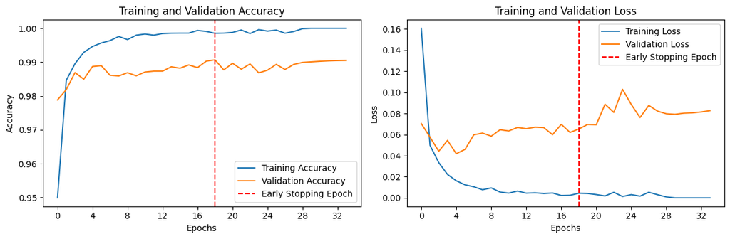

```
313/313 ━━━━━━━━━━━━━━━━━━━━ 0s 1ms/step - accuracy: 0.9875 - loss: 0.0571
Exactitud en el conjunto de prueba: 0.9904
Máxima exactitud en validación: 0.9907
1/1 ━━━━━━━━━━━━━━━━━━━━ 0s 42ms/step
Predicción: 6, Etiqueta verdadera: 1
```

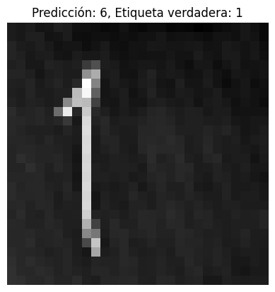

```
1/1 ━━━━━━━━━━━━━━━━━━━━ 0s 21ms/step
Predicción: 1, Etiqueta verdadera: 1
```

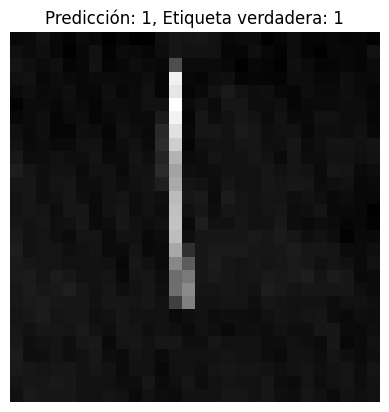

```
1/1 ━━━━━━━━━━━━━━━━━━━━ 0s 20ms/step
Predicción: 1, Etiqueta verdadera: 1
```

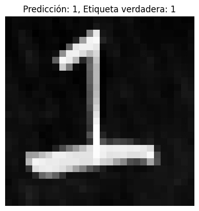

```
1/1 ━━━━━━━━━━━━━━━━━━━━ 0s 20ms/step
Predicción: 1, Etiqueta verdadera: 1
```

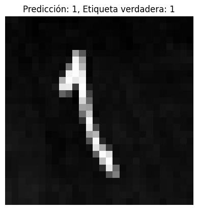

```
1/1 ━━━━━━━━━━━━━━━━━━━━ 0s 20ms/step
Predicción: 4, Etiqueta verdadera: 1
```

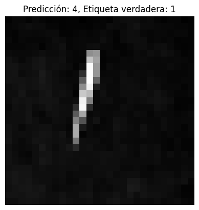

```
1/1 ━━━━━━━━━━━━━━━━━━━━ 0s 20ms/step
Predicción: 2, Etiqueta verdadera: 2
```

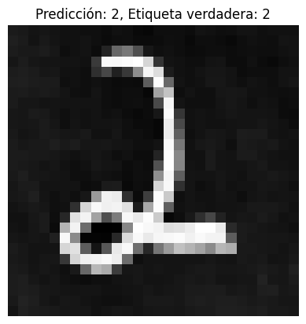

```
1/1 ━━━━━━━━━━━━━━━━━━━━ 0s 20ms/step
Predicción: 2, Etiqueta verdadera: 2
```

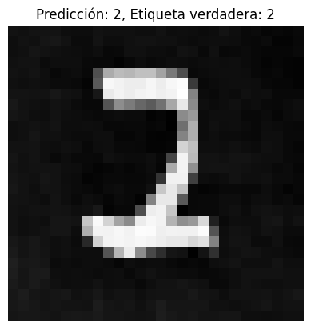

```
1/1 ━━━━━━━━━━━━━━━━━━━━ 0s 28ms/step
Predicción: 2, Etiqueta verdadera: 2
```

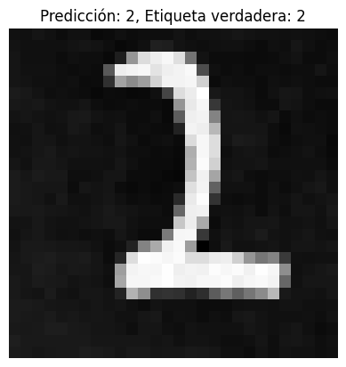

```
1/1 ━━━━━━━━━━━━━━━━━━━━ 0s 21ms/step
Predicción: 2, Etiqueta verdadera: 2
```

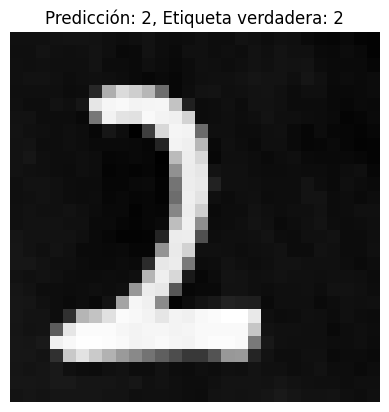

```
1/1 ━━━━━━━━━━━━━━━━━━━━ 0s 20ms/step
Predicción: 2, Etiqueta verdadera: 2
```

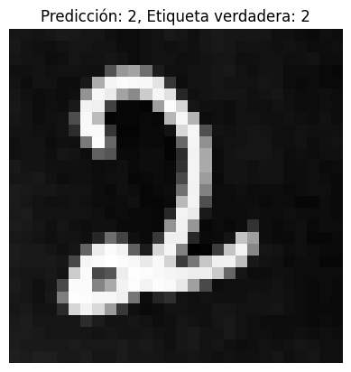

```
1/1 ━━━━━━━━━━━━━━━━━━━━ 0s 26ms/step
Predicción: 1, Etiqueta verdadera: 3
```

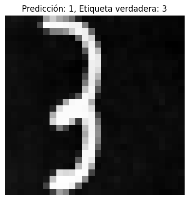

```
1/1 ━━━━━━━━━━━━━━━━━━━━ 0s 20ms/step
Predicción: 3, Etiqueta verdadera: 3
```

[40 more figures not shown]

```
Accuracy: 0.6600 (33/50)
```

```python
train_images=train_images.astype('float32')/255
test_images=test_images.astype('float32')/255
train_images=train_images.reshape((train_images.shape[0], 28, 28, 1))
test_images=test_images.reshape((test_images.shape[0], 28, 28, 1))
model=Sequential()
model.add(layers.Conv2D(32, (3, 3), padding='same', activation='relu', input_shape=(28, 28, 1)))
model.add(layers.MaxPooling2D((2, 2)))
model.add(layers.Conv2D(64, (3, 3), padding='same', activation='relu'))
model.add(layers.MaxPooling2D((2, 2)))
model.add(layers.Flatten())
model.add(layers.Dense(128, activation='relu'))
model.add(Dense(10, activation='softmax'))
model.compile(optimizer=Adam(learning_rate=0.001), loss='sparse_categorical_crossentropy', metrics=['accuracy'])
model.summary()
early_stop=EarlyStopping(monitor='val_accuracy', patience=15, restore_best_weights=True)
history=model.fit(train_images, train_labels, epochs=100, validation_split=0.4, batch_size=32, callbacks=[early_stop])
stopped_epoch=early_stop.stopped_epoch
best_epoch=stopped_epoch-early_stop.patience
plt.figure(figsize=(12, 4))
plt.subplot(1, 2, 1)
plt.plot(history.history['accuracy'], label='Training Accuracy')
plt.plot(history.history['val_accuracy'], label='Validation Accuracy')
plt.axvline(x=best_epoch, color='r', linestyle='--', label='Early Stopping Epoch')
plt.title('Training and Validation Accuracy')
plt.xlabel('Epochs')
plt.ylabel('Accuracy')
plt.gca().xaxis.set_major_locator(MaxNLocator(integer=True))
plt.legend()
plt.subplot(1, 2, 2)
plt.plot(history.history['loss'], label='Training Loss')
plt.plot(history.history['val_loss'], label='Validation Loss')
plt.axvline(x=best_epoch, color='r', linestyle='--', label='Early Stopping Epoch')
plt.title('Training and Validation Loss')
plt.xlabel('Epochs')
plt.ylabel('Loss')
plt.gca().xaxis.set_major_locator(MaxNLocator(integer=True))
plt.legend()
plt.tight_layout()
plt.show()
test_loss, test_accuracy=model.evaluate(test_images, test_labels)
print(f'Exactitud en el conjunto de prueba: {test_accuracy:.4f}')
best_val_accuracy=max(history.history['val_accuracy'])
print(f'Máxima exactitud en validación: {best_val_accuracy:.4f}')
model.save('my_model.keras')
y_pred=[]
correct_count=0
total_count=0
def convert_to_mnist_format(image_path):
    img=cv2.imread(image_path)
    gray=cv2.cvtColor(img, cv2.COLOR_BGR2GRAY)
    gray=255-gray
    resized=cv2.resize(gray, (28, 28), interpolation=cv2.INTER_AREA)
    normalized=resized.astype('float32')/255
    final_image=normalized.reshape(1, 28, 28, 1)
    return final_image
for i in range(1, 51):
    image_path=f'imagen{i}.jpg'
    final_image=convert_to_mnist_format(image_path)
    prediction=model.predict(final_image)
    predicted_label=np.argmax(prediction, axis=1)[0]
    y_pred.append(predicted_label)
    true_label=true_labels[i]
    if predicted_label==true_label:
        correct_count+=1
    total_count+=1
    print(f'Predicción: {predicted_label}, Etiqueta verdadera: {true_label}')
    plt.imshow(final_image[0].reshape(28, 28), cmap='gray')
    plt.title(f'Predicción: {predicted_label}, Etiqueta verdadera: {true_label}')
    plt.axis('off')
    plt.show()
accuracy=correct_count/total_count
plt.figure(figsize=(14, 12))
cm=confusion_matrix(y_true, y_pred, labels=range(10))
sns.heatmap(cm, annot=True, fmt='d', cmap='Greens', xticklabels=range(10), yticklabels=range(10))
plt.xlabel('Predicción')
plt.ylabel('Valor Real')
plt.title('Matriz de Confusión')
plt.show()
print(f"Accuracy: {accuracy:.4f} ({correct_count}/{total_count})")
```

Este código es el mismo que el de antes, sin embargo se realizaron cambios con ayuda de ChatGpt y Claude, primero se normalizaron los datos, esto porque favorece al entrenamiento de modelos, y como sabemos que las imágenes se procesan en RGB sabemos que se almacenan números enteros entre **0** y **255**, después se añadieron capas en nuestra red neuronal, un detalle importante es que se dice que al hacer una capa de red convolucional podemos obtener mejores resultados y por ultimo se realizaron cambios similares en la función que permite procesar las imágenes al formato en que se entreno la base de datos. Como se ve, se tardo más tiempo en entrenar el modelo, pero el accuracy mejoro tanto en los datos de prueba como con los de las imágenes que le cargamos. Este modelo se guardo en el repositorio para poder pasarlo a otro programa.

6. Considerando los cambios del punto anterior, genera un sistema que prediga en tiempo real los dígitos del **0** al **9** a partir de la imagen capturada por la cámara de la computadora, o algún otro dispositivo.

```python
#   Redes_Neuronales.py
```

Este es el nombre del archivo donde se ejecuto el programa en tiempo real, ese programa fue hecho en parte por mi aunque más que nada fue corregido por Claude.

**Firma de Honor:** Doy mi palabra que he realizado esta actividad con integridad académica